# QRM II Graded Assignment 2

# Week 5

1. Create a plot of the mean profits by month of release. Do you see any indication that month of release matters to the profits of the movie?
2. Estimate an OLS model which has as dependent variable the log of profits of a movie, and as independent variable the log of budget, a dummy for whether the movie was released in english or not, and a linear term for the month of release. Show a summary of the resulting model and interpret each coefficient.
3. Test for the hypothesis that the coefficient that belongs to month of release is zero.
4. Based on your plot in a.) do you consider the choice that month of release enters the model linearly under b.) reasonable? Estimate a specification that allows for a more flexible curve. In this new specification, test for the null hypothesis that month of release does not impact profits. This might require testing multiple terms at once.
5. One executive at the studio wants to time the release of the movie to a specific month of the year such that they can maximize revenue. Based on your model under d.), What would you advise the movie studio regarding the timing of the release of the movie?

The movie studio that you work at is releasing a new movie in 2026. It will be an English-spoken Thriller movie with a budget of 40,000,0000.

6. Estimate a model that is able to predict the revenue of this movie. Give its predicted revenue and include a 99% prediction interval.

*step a*

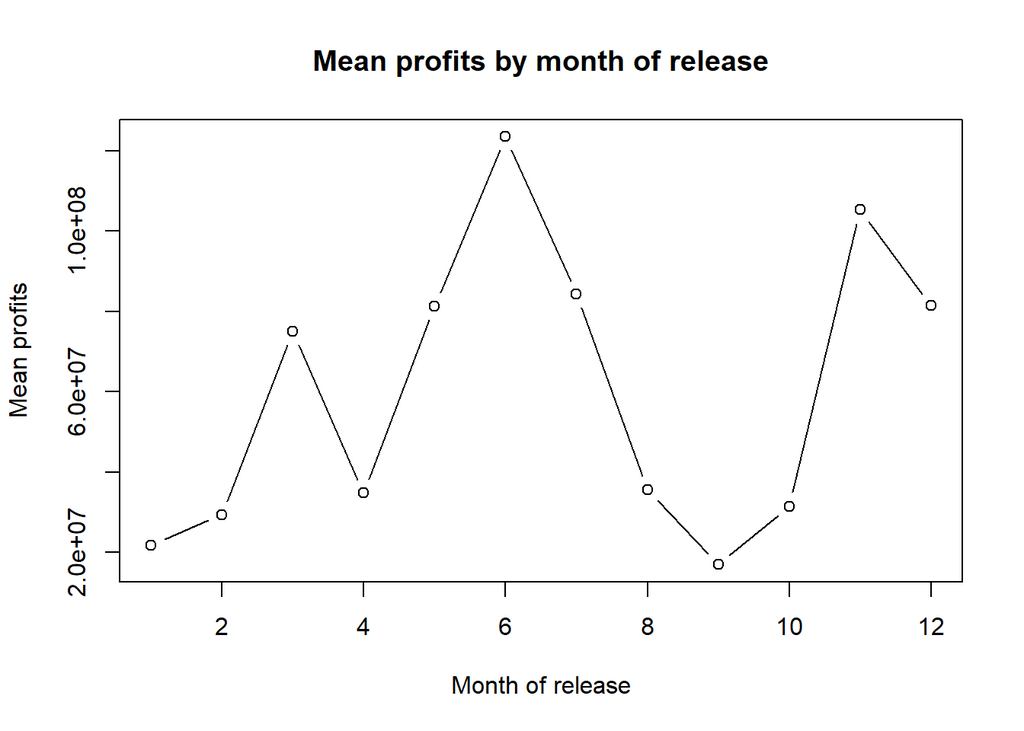

```r
movies5$profits <- movies5$revenue - movies5$budget

month_means <- aggregate(profits ~ release_month,
                         data = movies5,
                         FUN = mean,
                         na.rm = TRUE)

plot(month_means$release_month,
     month_means$profits,
     type = "b",
     xlab = "Month of release",
     ylab = "Mean profits",
     main = "Mean profits by month of release")
```

**Your Answer:**

The plot shows that average profits vary across the months. June and November have relatively high average profits, while September  
has relatively low average profits. This suggests that the month of release may matter for movie profits.

*step b*

```r
movies5$english <- ifelse(movies5$original_language == "en", 1, 0)

mod_month <- lm(logprofits ~ logbudget + english + release_month,
                data = movies5)

summary(mod_month)
```

```
##
## Call:
## lm(formula = logprofits ~ logbudget + english + release_month,
##     data = movies5)
##
## Residuals:
##     Min      1Q  Median      3Q     Max
## -7.2036 -0.6992  0.1714  0.8886  2.9585
##
## Coefficients:
##               Estimate Std. Error t value Pr(>|t|)
## (Intercept)    6.96828    0.81336   8.567   <2e-16 ***
## logbudget      0.57697    0.04488  12.857   <2e-16 ***
## english        0.72135    0.34411   2.096   0.0366 *
## release_month  0.02106    0.01836   1.147   0.2519
## ---
## Signif. codes:  0 '***' 0.001 '**' 0.01 '*' 0.05 '.' 0.1 ' ' 1
##
## Residual standard error: 1.34 on 459 degrees of freedom
##   (446 observations deleted due to missingness)
## Multiple R-squared:  0.2807, Adjusted R-squared:  0.276
## F-statistic: 59.72 on 3 and 459 DF,  p-value: < 2.2e-16
```

**Your Answer:**

The coefficient for Log Budget is approximately 0.577. This means that a 1% increase in budget is associated with approximately a 0.58% increase in profits, holding the other variables constant.

The coefficient for English is approximately 0.721. This means that English-language movies have approximately 106% higher profits than non-English movies, holding budget and release month constant.

The coefficient for Release Month is approximately 0.021. This means that moving one month later is associated with approximately a 2.1% increase in profits, holding budget and language constant.

*step c*

```r
summary(mod_month)
```

```
##
## Call:
## lm(formula = logprofits ~ logbudget + english + release_month,
##     data = movies5)
##
## Residuals:
##     Min      1Q  Median      3Q     Max
## -7.2036 -0.6992  0.1714  0.8886  2.9585
##
## Coefficients:
##               Estimate Std. Error t value Pr(>|t|)
## (Intercept)    6.96828    0.81336   8.567   <2e-16 ***
## logbudget      0.57697    0.04488  12.857   <2e-16 ***
## english        0.72135    0.34411   2.096   0.0366 *
## release_month  0.02106    0.01836   1.147   0.2519
## ---
## Signif. codes:  0 '***' 0.001 '**' 0.01 '*' 0.05 '.' 0.1 ' ' 1
##
## Residual standard error: 1.34 on 459 degrees of freedom
##   (446 observations deleted due to missingness)
## Multiple R-squared:  0.2807, Adjusted R-squared:  0.276
## F-statistic: 59.72 on 3 and 459 DF,  p-value: < 2.2e-16
```

**Your Answer:**

The p-value for the release month coefficient is approximately 0.252. Since this is greater than 0.05, we do not reject the null hypothesis that the coefficient of release month is zero. Therefore, there is no statistically significant evidence that release month has a linear effect on profits.

*step d*

```r
movies5$english <- ifelse(movies5$original_language == "en", 1, 0)
mod_flex <- lm(logprofits ~ logbudget + english + release_month + I(release_month^2), data = movies5)
mod_nomonth <- lm(logprofits ~ logbudget + english, data = movies5)
anova(mod_nomonth, mod_flex)
```

|  | Res.Df | RSS | Df | Sum of Sq | F | Pr(>F) |
| --- | --- | --- | --- | --- | --- | --- |
| 1 | 460 | 826.0958 | NA | NA | NA | NA |
| 2 | 458 | 822.3779 | 2 | 3.717889 | 1.035286 | 0.3559543 |

**Your Answer:**

Profits vary a lot by month in the plot from a) (June averages 123m, September only $17m), so a straight line might not fit well. Testing month and month^2 jointly gives F = 1.04, p = 0.356, so month has no significant effect once budget and language are in the model.

*step e*

```r
#WRITE YOUR CODE HERE
```

**Your Answer:**

Based on the model in (d), I wouldnt advise selecting a specific release month. once budget and language are accounted for, timing shows no real effect on profits. The pattern that summer and November releases look most profitable could mostly be because studios have already scheduled their biggest most expensive English-language films for those periods.

*step f*

```r
thrillers <- subset(movies5, genre == "Thriller")
thrillers <- thrillers[thrillers$revenue > 0, ]
mod_thriller <- lm(log(revenue) ~ logbudget + english, data = thrillers)

newmovie <- data.frame(logbudget = log(40000000), english = 1)
predict(mod_thriller, newdata = newmovie, interval = "prediction", level = 0.99)
```

```
##        fit      lwr      upr
## 1 18.08614 13.16505 23.00724
```

```r
exp(predict(mod_thriller, newdata = newmovie, interval = "prediction", level = 0.99))
```

```
##        fit    lwr        upr
## 1 71566843 521804 9815587435
```

The predicted revenue is about 71.5 million, with a 99% prediction interval of roughly 520,000 to 9.8 billion. The interval is extremely wide because theres a lot of variation in movie revenue than just budget and language.